[figure not shown]

[figure not shown]

# Overview

### Questions

The questions that this dashboard will answer are the following:

- Where are out students going (region)?
- What are the salary differentials by region?
- What types of jobs (By company) are students getting by region? Are bank and consulting jobs in Chicago and NYC?
- What are the top 3-5 job categories (by company) by city (Chicago, Cincinnati, Columbus, Cleveland)?

### Insights

- Top 4 placement cities for students graduating Miami University FSB is Chicago, Cincinnati, Columbus, and Cleveland.
- On average, the top paying city is NYC, however it is shocking that it is just over $67,000. The top paying state is California with New York to shortly follow.
- Accounting and Finance are the top type of jobs in Chicago and NYC. Chicago does have a handful of alumni doing Consulting at West Monroe Partners.
- EY and Deloitte is the in the top 3 companies for Cincinnati, Chicago and Cleveland.

# Placement

### Where are students going in the USA?

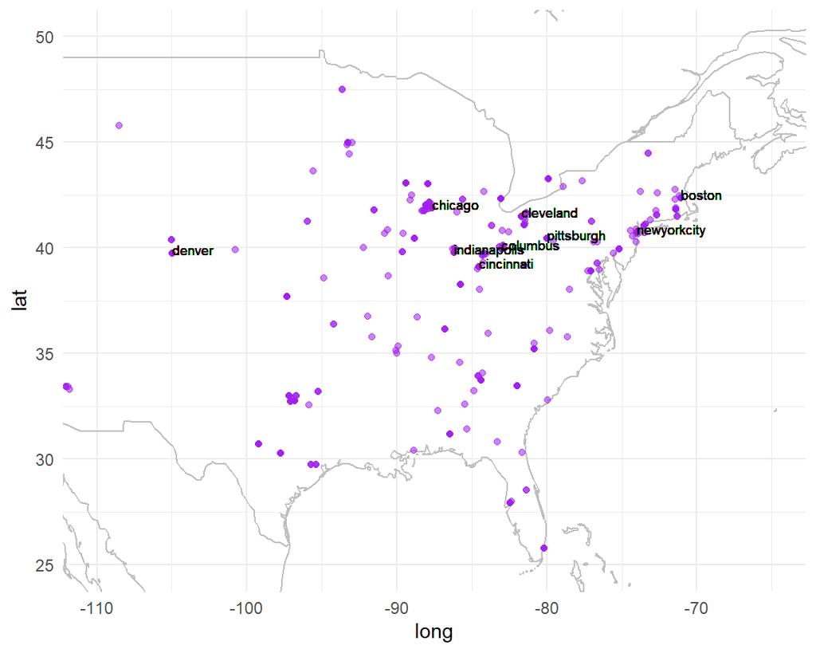

### Top 10 Placement Cities

| City | Number of Students |
| --- | --- |
| chicago | 501 |
| cincinnati | 240 |
| columbus | 188 |
| cleveland | 131 |
| newyorkcity | 64 |
| indianapolis | 33 |
| denver | 28 |
| boston | 26 |
| pittsburgh | 23 |
| dayton | 21 |

[output cut: 246 more lines]

# Salary

### Average Salary per State

[output not shown]

[output cut: 9 more lines]

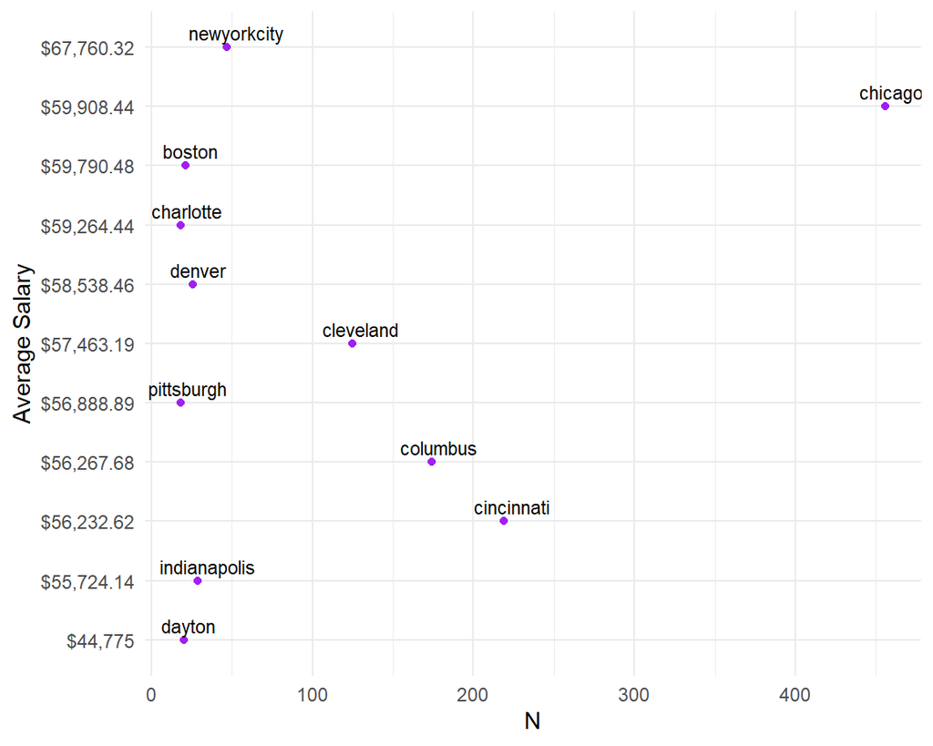

# Company Composition

## column

### What types of jobs (By company) are students getting by region?

| City | Company | Number of Students |
| --- | --- | --- |
| cincinnati | deloitte | 41 |
| chicago | ey | 40 |
| chicago | deloitte | 27 |
| columbus | abercrombie &amp; fitch | 22 |
| chicago | coyote logistics | 20 |
| columbus | jp morgan | 16 |
| cleveland | keybanc capital markets | 16 |
| cincinnati | terillium | 16 |
| chicago | arrive logistics | 15 |
| columbus | dhl | 15 |

[output cut: 1079 more lines]

## column

### Are bank and consulting jobs in Chicago and NYC?

#### NYC

| City | Company | Job Position | Salary | Number of Students |
| --- | --- | --- | --- | --- |
| NYC | ey |  | 70000 | 2 |
| NYC | oppenheimer &amp; co inc. |  |  | 2 |
| NYC | pwc | Finance | 85000 | 2 |
| NYC | the home depot |  |  | 2 |
| NYC | a j gallagher | Consulting Human Resources Marketing / Sales |  | 1 |
| NYC | alphasights | Consulting | 60000 | 1 |
| NYC | alphasights | Consulting Other: Information Services | 60000 | 1 |
| NYC | american eagle outfitters | Analytics Marketing / Sales Other: Fashion Merchandising | 55000 | 1 |
| NYC | american eagle outfitters | Marketing / Sales | 58240 | 1 |
| NYC | american eagle outfitters | Marketing/Sales | 55000 | 1 |

[output cut: 50 more lines]

#### Chicago

| City | Company | Job Position | Salary | Number of Students |
| --- | --- | --- | --- | --- |
| chicago | ey | Accounting | 62000 | 13 |
| chicago | deloitte | Accounting | 60000 | 10 |
| chicago | west monroe partners | Consulting | 70000 | 7 |
| chicago | cdw | Marketing / Sales | 30000 | 6 |
| chicago | deloitte | Accounting | 62000 | 6 |
| chicago | coyote logistics | Marketing / Sales | 45000 | 5 |
| chicago | capgemini invent | Consulting | 75000 | 4 |
| chicago | fifth third bank | Finance | 63000 | 4 |
| chicago | rsm | Accounting | 62500 | 4 |
| chicago | the home depot | Consulting | 73000 | 4 |

[output cut: 388 more lines]

# Top 3-5 Companies by City

What are the top 3-5 job categories (by company) by city (Chicago, Cincinnati, Cleveland, Columbus)?

## row

### Chicago

| City | Company | Number of Students |
| --- | --- | --- |
| chicago | ey | 40 |
| chicago | deloitte | 27 |
| chicago | coyote logistics | 20 |
| chicago | arrive logistics | 15 |
| chicago | west monroe partners | 15 |

### Cleveland

| City | Company | Number of Students |
| --- | --- | --- |
| cleveland | keybanc capital markets | 16 |
| cleveland | deloitte | 13 |
| cleveland | ey | 12 |
| cleveland | quicken loans | 8 |
| cleveland | insight2profit | 5 |

## row

### Cincinnati

| City | Company | Number of Students |
| --- | --- | --- |
| cincinnati | deloitte | 41 |
| cincinnati | terillium | 16 |
| cincinnati | ey | 9 |
| cincinnati | fifth third bank | 9 |
| cincinnati | fis | 7 |

### Columbus

| City | Company | Number of Students |
| --- | --- | --- |
| columbus | abercrombie &amp; fitch | 22 |
| columbus | jp morgan | 16 |
| columbus | dhl | 15 |
| columbus | kpmg | 11 |
| columbus | crowe | 9 |